# Popularnost Spotify pjesama

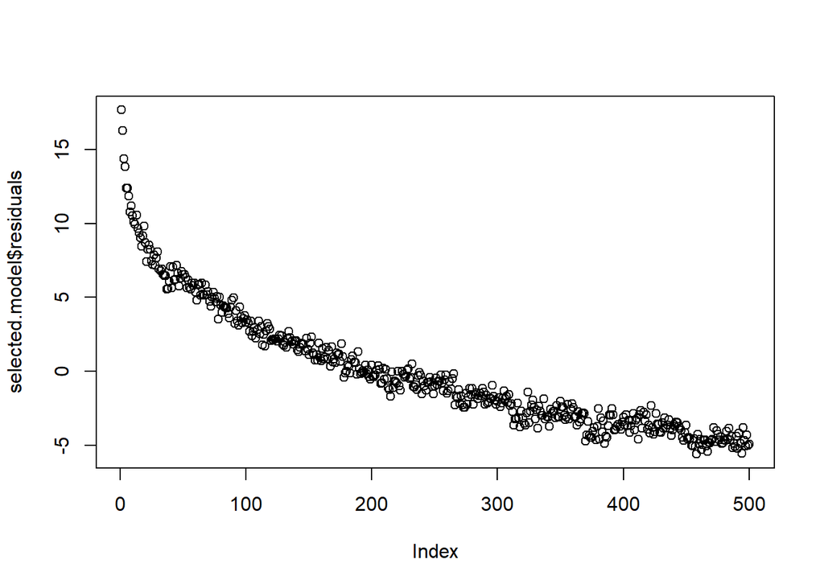

```r
plot(selected.model$residuals)
```

```r
selected.model = fit.speechiness
summary(fit.speechiness)
```

```
##
## Call:
## lm(formula = popularity ~ speechiness, data = genreDataTrim)
##
## Residuals:
##    Min     1Q Median     3Q    Max
## -5.092 -3.287 -1.021  2.075 18.031
##
## Coefficients:
##             Estimate Std. Error t value Pr(>|t|)
## (Intercept)  74.1804     0.2912 254.706   <2e-16 ***
## speechiness  -3.4086     1.9761  -1.725   0.0852 .
## ---
## Signif. codes:  0 '***' 0.001 '**' 0.01 '*' 0.05 '.' 0.1 ' ' 1
##
## Residual standard error: 4.161 on 498 degrees of freedom
## Multiple R-squared:  0.005939,   Adjusted R-squared:  0.003943
## F-statistic: 2.975 on 1 and 498 DF,  p-value: 0.08516
```

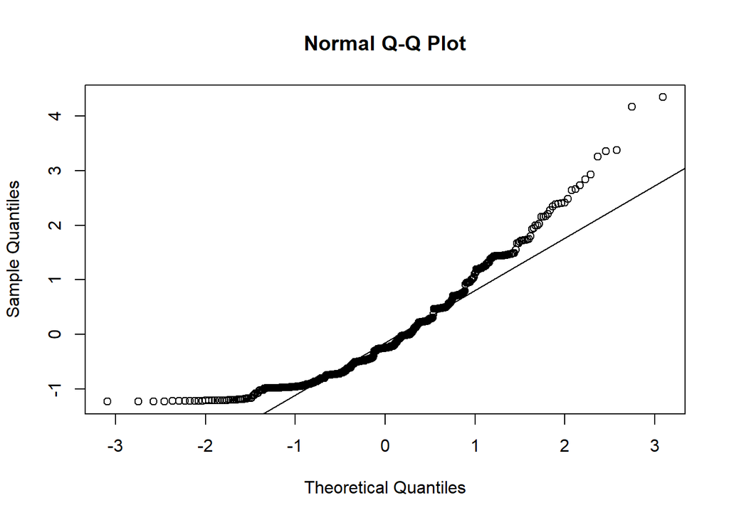

```r
qqnorm(rstandard(selected.model))
qqline(rstandard(selected.model))
```

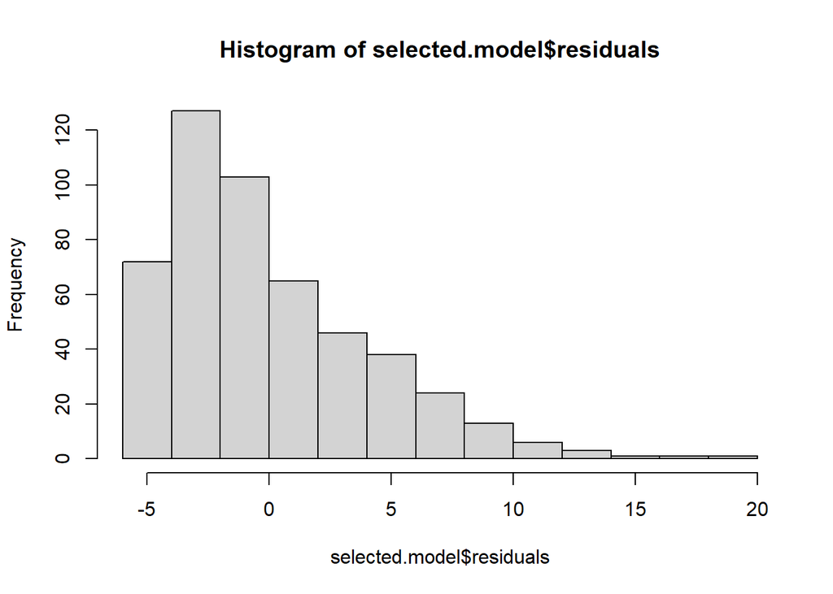

```r
hist(selected.model$residuals)
```

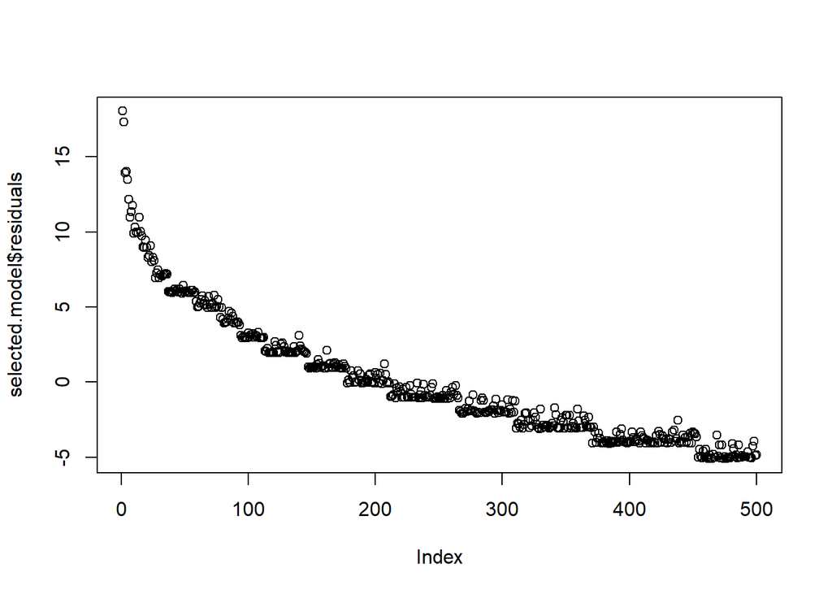

```r
plot(selected.model$residuals)
```

```r
lillie.test(rstandard(fit.speechiness))
```

```
##
##  Lilliefors (Kolmogorov-Smirnov) normality test
##
## data:  rstandard(fit.speechiness)
## D = 0.12013, p-value < 2.2e-16
```

Histogrami i qq-plotova nam ukazuju na “slabe” lijeve repove. P-vrijednost je jako mala za svaki test, čak i uz korištenje preporučene Lillieforsove inačice. Stoga, ne možemo donositi zaključke iz ovih regresijskih modela.

## Višestruka regresija

Prije nego procjenimo model višestruke regresije moramo provjeriti da pojedini parovi varijabli nisu (previše) korelirani.

```r
cor(cbind(genreDataTrim$loudness, genreDataTrim$energy, genreDataTrim$speechiness)) # korelacijski koeficijenti parova regresora
```

```
##             [,1]      [,2]        [,3]
## [1,]  1.00000000 0.7351149 -0.01080719
## [2,]  0.73511486 1.0000000  0.11998491
## [3,] -0.01080719 0.1199849  1.00000000
```

Pošto su loudness i energy jako korelirane regresija s njima će nam dati neke rezultate, ali na temelju njih ne bi smjeli donositi zaključke. Stoga ćemo probati oba slučaja, odnosno kombinacije loudness + speechiness i energy + speechiness.

```r
fit.multi = lm(popularity ~ loudness + speechiness, genreDataTrim)
summary(fit.multi)
```

```
##
## Call:
## lm(formula = popularity ~ loudness + speechiness, data = genreDataTrim)
##
## Residuals:
##    Min     1Q Median     3Q    Max
## -5.926 -3.231 -0.894  2.279 17.579
##
## Coefficients:
##             Estimate Std. Error t value Pr(>|t|)
## (Intercept) 75.89826    0.59825 126.868  < 2e-16 ***
## loudness     0.25243    0.07702   3.277  0.00112 **
## speechiness -3.33927    1.95715  -1.706  0.08860 .
## ---
## Signif. codes:  0 '***' 0.001 '**' 0.01 '*' 0.05 '.' 0.1 ' ' 1
##
## Residual standard error: 4.121 on 497 degrees of freedom
## Multiple R-squared:  0.02697,    Adjusted R-squared:  0.02305
## F-statistic: 6.888 on 2 and 497 DF,  p-value: 0.00112
```

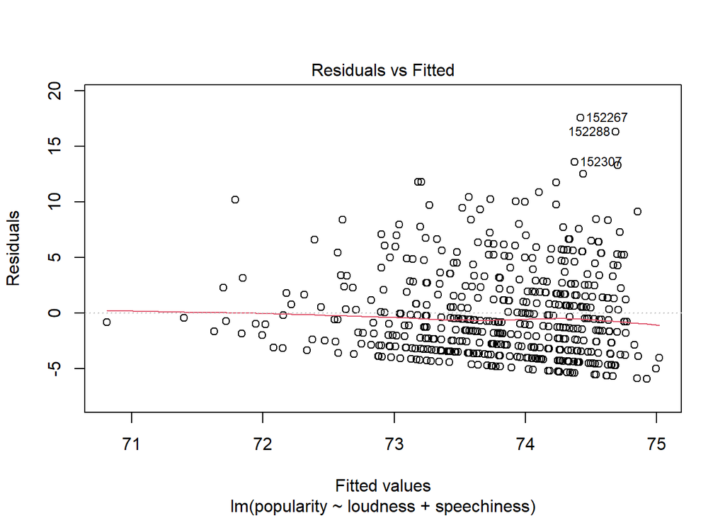

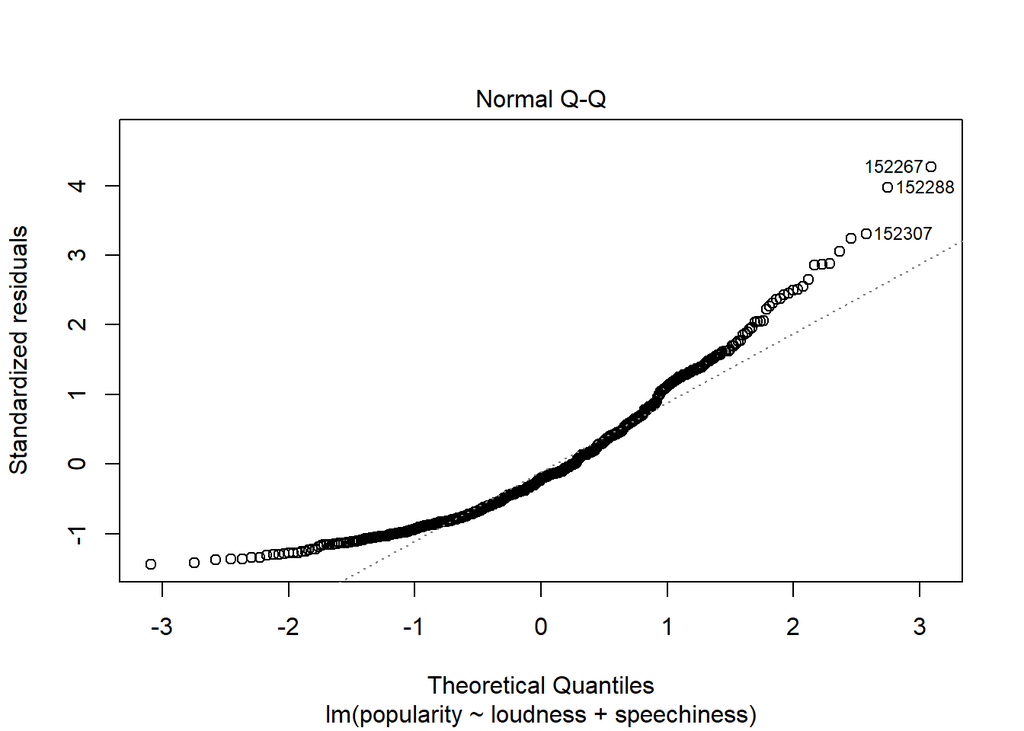

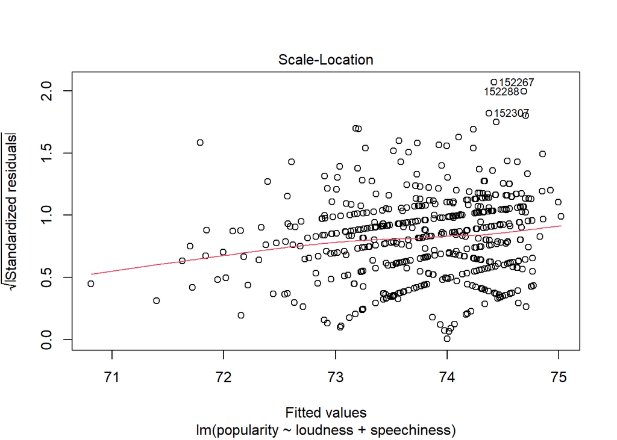

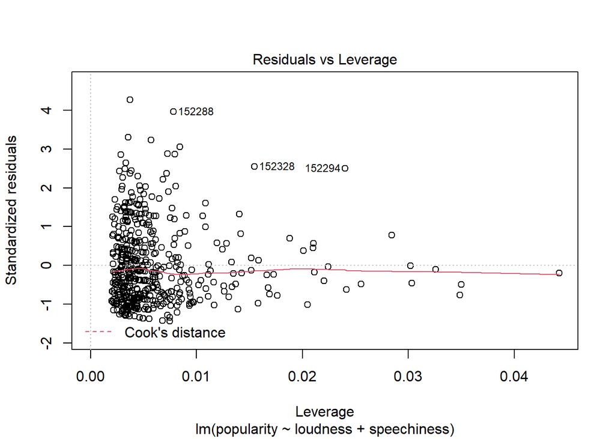

```r
plot(fit.multi)
```

```r
fit.multi = lm(popularity ~ speechiness + energy, genreDataTrim)
summary(fit.multi)
```

```
##
## Call:
## lm(formula = popularity ~ speechiness + energy, data = genreDataTrim)
##
## Residuals:
##     Min      1Q  Median      3Q     Max
## -5.8703 -3.1898 -0.9016  2.1600 17.3980
##
## Coefficients:
##             Estimate Std. Error t value Pr(>|t|)
## (Intercept)  72.3288     0.6944 104.162  < 2e-16 ***
## speechiness  -4.1037     1.9754  -2.077  0.03828 *
## energy        3.3352     1.1372   2.933  0.00351 **
## ---
## Signif. codes:  0 '***' 0.001 '**' 0.01 '*' 0.05 '.' 0.1 ' ' 1
##
## Residual standard error: 4.13 on 497 degrees of freedom
## Multiple R-squared:  0.02285,    Adjusted R-squared:  0.01892
## F-statistic: 5.811 on 2 and 497 DF,  p-value: 0.003202
```

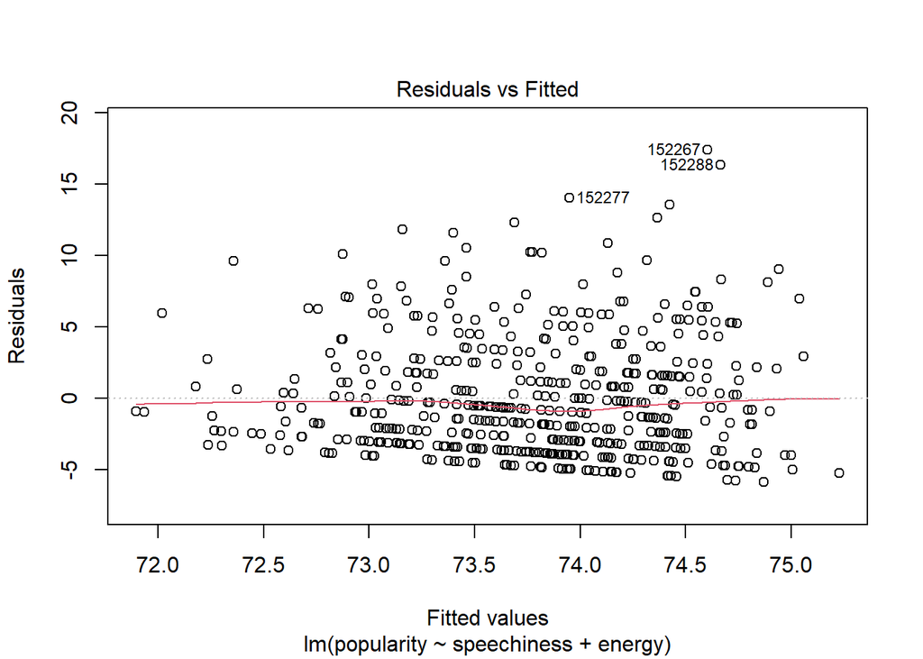

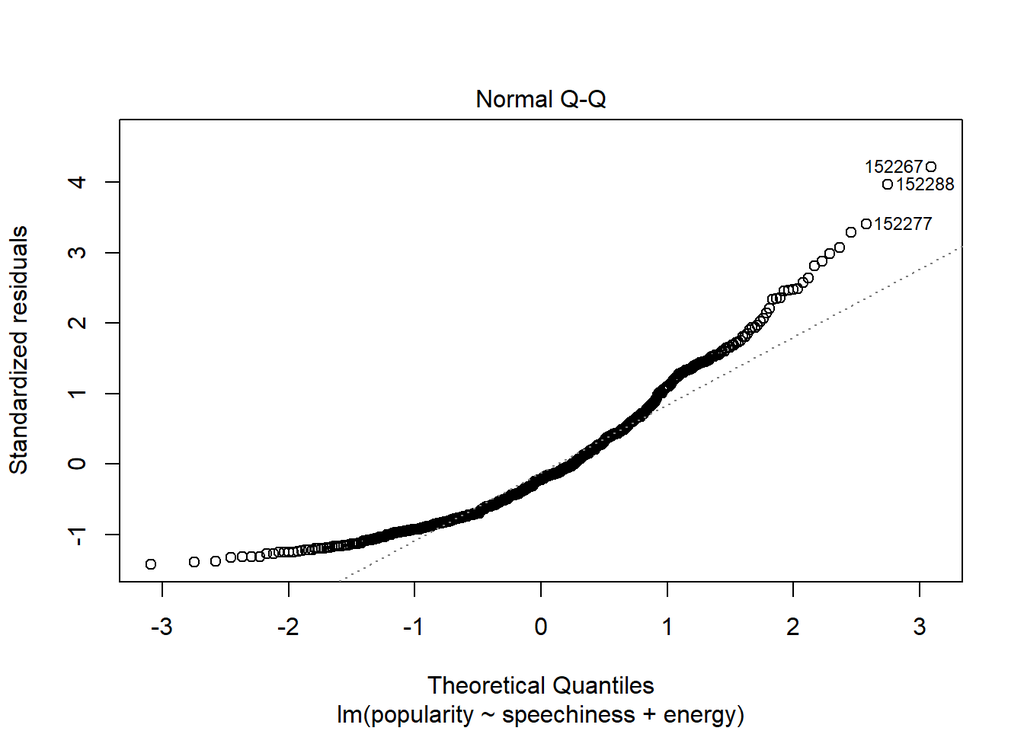

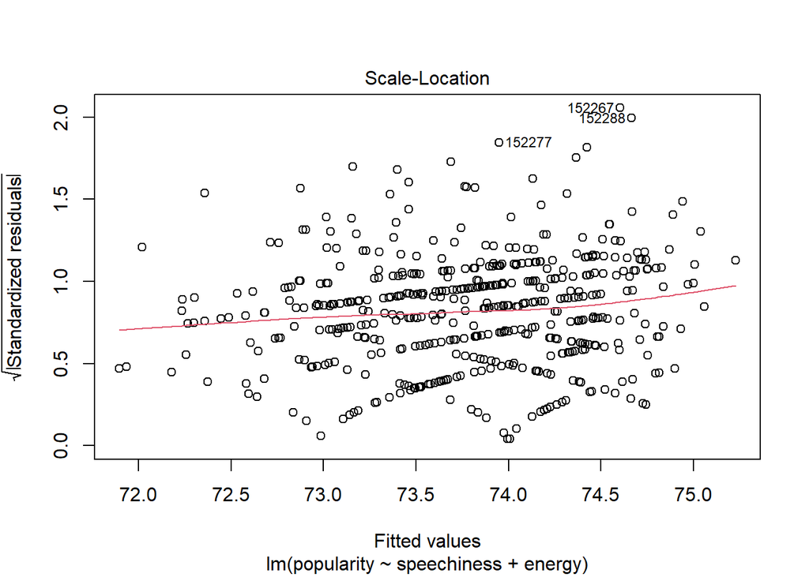

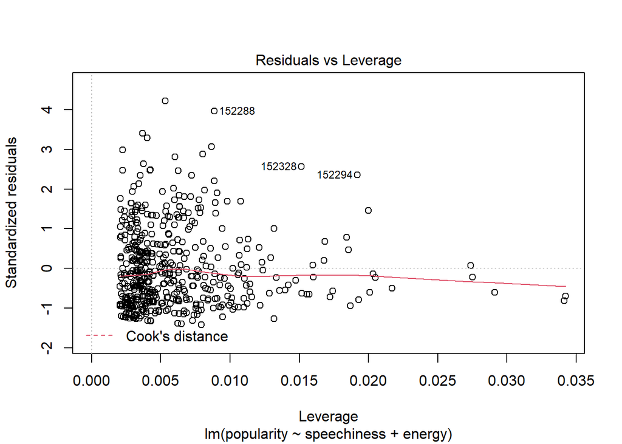

```r
plot(fit.multi)
```

Vidimo da model kombinacije loudness + speechiness bolji jer dobijemo R^2 0.02305, što je ujedno i najbolji model jer ima najveći R^2.

Pošto smo vidjeli da nijedna varijabla niti kombinacija varijabli ne utječe pretjerano na popularnost, pogledat ćemo kako utječu imena izvođača.

Iz dataseta smo stvorili podskup po umjetnicima koji sadrži prosječnu popularnost njihovih pjesama. Iz njega smo eliminirali umjetnike sa manje od 20 pjesama.

```r
library(tidyverse)

options(warn = -1)

genreData %>% group_by(name = artist_name) %>% summarise(
    avgPopularity = mean(popularity),
    songCount = nrow(genreData[which((genreData$artist_name) == name),])
) -> pop

pop = pop[which(pop$songCount > 20),]
pop = pop[order(-pop$avgPopularity),]

top10Artist = pop[1:10,]
top10Artist
```

```
## # A tibble: 10 x 3
##    name              avgPopularity songCount
##    <chr>                     <dbl>     <int>
##  1 Joji                       66.3        24
##  2 Frank Ocean                66.0        35
##  3 Rex Orange County          65.9        24
##  4 6LACK                      65.1        34
##  5 The Weeknd                 64.4        87
##  6 Zara Larsson               64.3        21
##  7 Ella Mai                   64.2        33
##  8 Jorja Smith                62.9        29
##  9 SZA                        62.3        25
## 10 H.E.R.                     62.1        39
```

```r
thirdQuantile = quantile(genreData$popularity, c(0.75))
thirdQuantile
```

```
## 75%
##  58
```

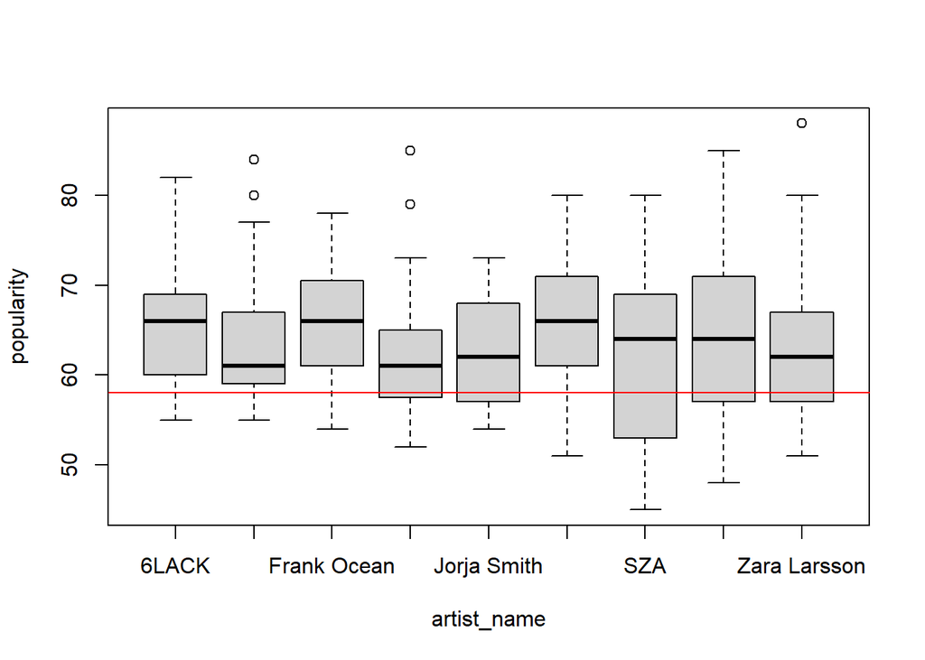

```r
newData = genreData[which(genreData$artist_name == top10Artist[i,]$name),]

for (i in 2:10) {
  newData <- rbind(newData, (genreData[which(genreData$artist_name == top10Artist[i,]$name),]))
}

boxplot(popularity ~ artist_name, data=newData)
abline(h=58, col="red")
```